# Risk Factor Analysis

## Outcome Variable

**Outcome Variable:** wast_rec90d

## Predictor Variables

**Intervention Variable:** pers_wast

**Adjustment Set:**

unadjusted

## Stratifying Variables

The analysis was stratified on these variable(s):

- agecat
- studyid
- country

## Data Summary

| agecat | studyid | country | pers_wast | wast_rec90d | n_cell | n |
| --- | --- | --- | --- | --- | --- | --- |
| 0-24 months | ki0047075b-MAL-ED | BANGLADESH | 0 | 0 | 35 | 124 |
| 0-24 months | ki0047075b-MAL-ED | BANGLADESH | 0 | 1 | 76 | 124 |
| 0-24 months | ki0047075b-MAL-ED | BANGLADESH | 1 | 0 | 10 | 124 |
| 0-24 months | ki0047075b-MAL-ED | BANGLADESH | 1 | 1 | 3 | 124 |
| 0-24 months | ki0047075b-MAL-ED | BRAZIL | 0 | 0 | 5 | 23 |
| 0-24 months | ki0047075b-MAL-ED | BRAZIL | 0 | 1 | 17 | 23 |
| 0-24 months | ki0047075b-MAL-ED | BRAZIL | 1 | 0 | 1 | 23 |
| 0-24 months | ki0047075b-MAL-ED | BRAZIL | 1 | 1 | 0 | 23 |
| 0-24 months | ki0047075b-MAL-ED | INDIA | 0 | 0 | 50 | 178 |
| 0-24 months | ki0047075b-MAL-ED | INDIA | 0 | 1 | 101 | 178 |
| 0-24 months | ki0047075b-MAL-ED | INDIA | 1 | 0 | 21 | 178 |
| 0-24 months | ki0047075b-MAL-ED | INDIA | 1 | 1 | 6 | 178 |
| 0-24 months | ki0047075b-MAL-ED | NEPAL | 0 | 0 | 14 | 93 |
| 0-24 months | ki0047075b-MAL-ED | NEPAL | 0 | 1 | 68 | 93 |
| 0-24 months | ki0047075b-MAL-ED | NEPAL | 1 | 0 | 6 | 93 |
| 0-24 months | ki0047075b-MAL-ED | NEPAL | 1 | 1 | 5 | 93 |
| 0-24 months | ki0047075b-MAL-ED | PERU | 0 | 0 | 6 | 34 |
| 0-24 months | ki0047075b-MAL-ED | PERU | 0 | 1 | 28 | 34 |
| 0-24 months | ki0047075b-MAL-ED | PERU | 1 | 0 | 0 | 34 |
| 0-24 months | ki0047075b-MAL-ED | PERU | 1 | 1 | 0 | 34 |
| 0-24 months | ki0047075b-MAL-ED | SOUTH AFRICA | 0 | 0 | 10 | 83 |
| 0-24 months | ki0047075b-MAL-ED | SOUTH AFRICA | 0 | 1 | 65 | 83 |
| 0-24 months | ki0047075b-MAL-ED | SOUTH AFRICA | 1 | 0 | 7 | 83 |
| 0-24 months | ki0047075b-MAL-ED | SOUTH AFRICA | 1 | 1 | 1 | 83 |
| 0-24 months | ki0047075b-MAL-ED | TANZANIA, UNITED REPUBLIC OF | 0 | 0 | 8 | 45 |
| 0-24 months | ki0047075b-MAL-ED | TANZANIA, UNITED REPUBLIC OF | 0 | 1 | 37 | 45 |
| 0-24 months | ki0047075b-MAL-ED | TANZANIA, UNITED REPUBLIC OF | 1 | 0 | 0 | 45 |
| 0-24 months | ki0047075b-MAL-ED | TANZANIA, UNITED REPUBLIC OF | 1 | 1 | 0 | 45 |
| 0-24 months | ki1000108-CMC-V-BCS-2002 | INDIA | 0 | 0 | 60 | 325 |
| 0-24 months | ki1000108-CMC-V-BCS-2002 | INDIA | 0 | 1 | 180 | 325 |

[output cut: 198 more lines]

The following strata were considered:

- agecat: 0-24 months, studyid: ki0047075b-MAL-ED, country: BANGLADESH
- agecat: 0-24 months, studyid: ki0047075b-MAL-ED, country: BRAZIL
- agecat: 0-24 months, studyid: ki0047075b-MAL-ED, country: INDIA
- agecat: 0-24 months, studyid: ki0047075b-MAL-ED, country: NEPAL
- agecat: 0-24 months, studyid: ki0047075b-MAL-ED, country: PERU
- agecat: 0-24 months, studyid: ki0047075b-MAL-ED, country: SOUTH AFRICA
- agecat: 0-24 months, studyid: ki0047075b-MAL-ED, country: TANZANIA, UNITED REPUBLIC OF
- agecat: 0-24 months, studyid: ki1000108-CMC-V-BCS-2002, country: INDIA
- agecat: 0-24 months, studyid: ki1000108-IRC, country: INDIA
- agecat: 0-24 months, studyid: ki1000109-EE, country: PAKISTAN
- agecat: 0-24 months, studyid: ki1000109-ResPak, country: PAKISTAN
- agecat: 0-24 months, studyid: ki1017093b-PROVIDE, country: BANGLADESH
- agecat: 0-24 months, studyid: ki1066203-TanzaniaChild2, country: TANZANIA, UNITED REPUBLIC OF
- agecat: 0-24 months, studyid: ki1101329-Keneba, country: GAMBIA
- agecat: 0-24 months, studyid: ki1112895-Guatemala BSC, country: GUATEMALA
- agecat: 0-24 months, studyid: ki1113344-GMS-Nepal, country: NEPAL
- agecat: 0-24 months, studyid: ki1114097-CMIN, country: BANGLADESH
- agecat: 0-24 months, studyid: ki1114097-CMIN, country: PERU
- agecat: 0-24 months, studyid: ki1114097-CONTENT, country: PERU
- agecat: 0-6 months, studyid: ki0047075b-MAL-ED, country: BANGLADESH
- agecat: 0-6 months, studyid: ki0047075b-MAL-ED, country: BRAZIL
- agecat: 0-6 months, studyid: ki0047075b-MAL-ED, country: INDIA
- agecat: 0-6 months, studyid: ki0047075b-MAL-ED, country: NEPAL
- agecat: 0-6 months, studyid: ki0047075b-MAL-ED, country: PERU
- agecat: 0-6 months, studyid: ki0047075b-MAL-ED, country: SOUTH AFRICA
- agecat: 0-6 months, studyid: ki0047075b-MAL-ED, country: TANZANIA, UNITED REPUBLIC OF
- agecat: 0-6 months, studyid: ki1000108-CMC-V-BCS-2002, country: INDIA
- agecat: 0-6 months, studyid: ki1000108-IRC, country: INDIA
- agecat: 0-6 months, studyid: ki1000109-EE, country: PAKISTAN
- agecat: 0-6 months, studyid: ki1000109-ResPak, country: PAKISTAN
- agecat: 0-6 months, studyid: ki1017093b-PROVIDE, country: BANGLADESH
- agecat: 0-6 months, studyid: ki1066203-TanzaniaChild2, country: TANZANIA, UNITED REPUBLIC OF
- agecat: 0-6 months, studyid: ki1101329-Keneba, country: GAMBIA
- agecat: 0-6 months, studyid: ki1112895-Guatemala BSC, country: GUATEMALA
- agecat: 0-6 months, studyid: ki1113344-GMS-Nepal, country: NEPAL
- agecat: 0-6 months, studyid: ki1114097-CMIN, country: BANGLADESH
- agecat: 0-6 months, studyid: ki1114097-CMIN, country: PERU
- agecat: 0-6 months, studyid: ki1114097-CONTENT, country: PERU
- agecat: 6-24 months, studyid: ki0047075b-MAL-ED, country: BANGLADESH
- agecat: 6-24 months, studyid: ki0047075b-MAL-ED, country: BRAZIL
- agecat: 6-24 months, studyid: ki0047075b-MAL-ED, country: INDIA
- agecat: 6-24 months, studyid: ki0047075b-MAL-ED, country: NEPAL
- agecat: 6-24 months, studyid: ki0047075b-MAL-ED, country: PERU
- agecat: 6-24 months, studyid: ki0047075b-MAL-ED, country: SOUTH AFRICA
- agecat: 6-24 months, studyid: ki0047075b-MAL-ED, country: TANZANIA, UNITED REPUBLIC OF
- agecat: 6-24 months, studyid: ki1000108-CMC-V-BCS-2002, country: INDIA
- agecat: 6-24 months, studyid: ki1000108-IRC, country: INDIA
- agecat: 6-24 months, studyid: ki1000109-EE, country: PAKISTAN
- agecat: 6-24 months, studyid: ki1000109-ResPak, country: PAKISTAN
- agecat: 6-24 months, studyid: ki1017093b-PROVIDE, country: BANGLADESH
- agecat: 6-24 months, studyid: ki1066203-TanzaniaChild2, country: TANZANIA, UNITED REPUBLIC OF
- agecat: 6-24 months, studyid: ki1101329-Keneba, country: GAMBIA
- agecat: 6-24 months, studyid: ki1112895-Guatemala BSC, country: GUATEMALA
- agecat: 6-24 months, studyid: ki1113344-GMS-Nepal, country: NEPAL
- agecat: 6-24 months, studyid: ki1114097-CMIN, country: BANGLADESH
- agecat: 6-24 months, studyid: ki1114097-CMIN, country: PERU
- agecat: 6-24 months, studyid: ki1114097-CONTENT, country: PERU

### Dropped Strata

Some strata were dropped due to rare outcomes:

- agecat: 0-24 months, studyid: ki0047075b-MAL-ED, country: BANGLADESH
- agecat: 0-24 months, studyid: ki0047075b-MAL-ED, country: BRAZIL
- agecat: 0-24 months, studyid: ki0047075b-MAL-ED, country: PERU
- agecat: 0-24 months, studyid: ki0047075b-MAL-ED, country: SOUTH AFRICA
- agecat: 0-24 months, studyid: ki0047075b-MAL-ED, country: TANZANIA, UNITED REPUBLIC OF
- agecat: 0-24 months, studyid: ki1112895-Guatemala BSC, country: GUATEMALA
- agecat: 0-24 months, studyid: ki1114097-CONTENT, country: PERU
- agecat: 0-6 months, studyid: ki0047075b-MAL-ED, country: BANGLADESH
- agecat: 0-6 months, studyid: ki0047075b-MAL-ED, country: BRAZIL
- agecat: 0-6 months, studyid: ki0047075b-MAL-ED, country: NEPAL
- agecat: 0-6 months, studyid: ki0047075b-MAL-ED, country: PERU
- agecat: 0-6 months, studyid: ki0047075b-MAL-ED, country: SOUTH AFRICA
- agecat: 0-6 months, studyid: ki0047075b-MAL-ED, country: TANZANIA, UNITED REPUBLIC OF
- agecat: 0-6 months, studyid: ki1017093b-PROVIDE, country: BANGLADESH
- agecat: 0-6 months, studyid: ki1112895-Guatemala BSC, country: GUATEMALA
- agecat: 0-6 months, studyid: ki1114097-CMIN, country: BANGLADESH
- agecat: 0-6 months, studyid: ki1114097-CMIN, country: PERU
- agecat: 0-6 months, studyid: ki1114097-CONTENT, country: PERU
- agecat: 6-24 months, studyid: ki0047075b-MAL-ED, country: BANGLADESH
- agecat: 6-24 months, studyid: ki0047075b-MAL-ED, country: BRAZIL
- agecat: 6-24 months, studyid: ki0047075b-MAL-ED, country: INDIA
- agecat: 6-24 months, studyid: ki0047075b-MAL-ED, country: NEPAL
- agecat: 6-24 months, studyid: ki0047075b-MAL-ED, country: PERU
- agecat: 6-24 months, studyid: ki0047075b-MAL-ED, country: SOUTH AFRICA
- agecat: 6-24 months, studyid: ki0047075b-MAL-ED, country: TANZANIA, UNITED REPUBLIC OF
- agecat: 6-24 months, studyid: ki1000109-EE, country: PAKISTAN
- agecat: 6-24 months, studyid: ki1000109-ResPak, country: PAKISTAN
- agecat: 6-24 months, studyid: ki1017093b-PROVIDE, country: BANGLADESH
- agecat: 6-24 months, studyid: ki1112895-Guatemala BSC, country: GUATEMALA
- agecat: 6-24 months, studyid: ki1114097-CMIN, country: BANGLADESH
- agecat: 6-24 months, studyid: ki1114097-CMIN, country: PERU
- agecat: 6-24 months, studyid: ki1114097-CONTENT, country: PERU

## Methods Detail

We’re interested in the causal parameters $E[Y_a]$ for all values of $a \in \mathcal{A}$. These parameters represent the mean outcome if, possibly contrary to fact, we intervened to set all units to have $A=a$. Under the randomization and positivity assumptions, these are identified by the statistical parameters $\psi_a=E_W[E_{Y|A,W}(Y|A=a,W)]$. In addition, we’re interested in the mean of $Y$, $E[Y]$ under no intervention (the observed mean). We will estimate these parameters by using SuperLearner to fit the relevant likelihood factors – $E_{Y|A,W}(Y|A=a,W)$ and $p(A=a|W)$, and then updating our likelihood fit using a joint TMLE.

For unadjusted analyses ($W=\{\}$), initial likelihoods were estimated using Lrnr_glm to estimate the simple $E(Y|A)$ and Lrnr_mean to estimate $p(A)$. For adjusted analyses, a small library containing Lrnr_glmnet, Lrnr_xgboost, and Lrnr_mean was used.

Having estimated these parameters, we will then use the delta method to estimate relative risks and attributable risks relative to a prespecified baseline level of $A$.

# Results Detail

## Results Plots

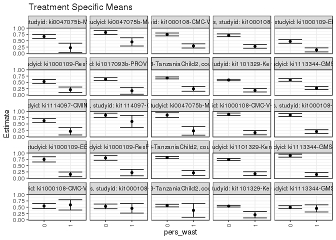

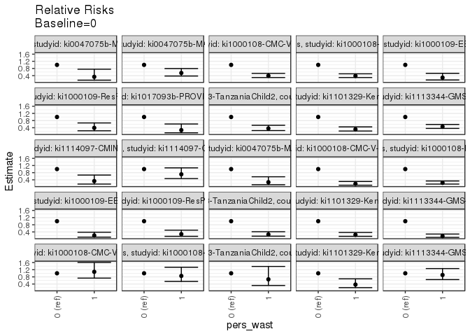

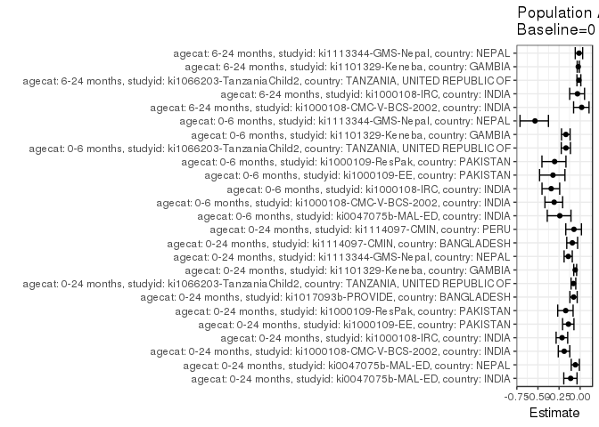

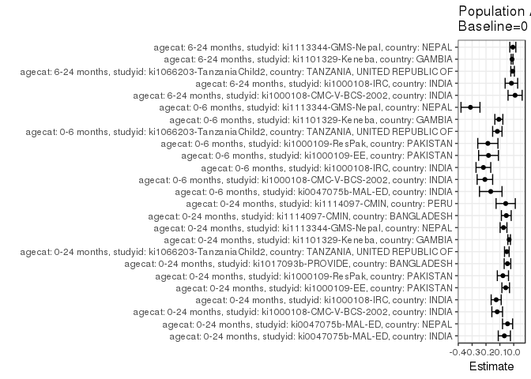

## Results Table

### Parameter: TSM

| agecat | studyid | country | intervention_level | baseline_level | estimate | ci_lower | ci_upper |
| --- | --- | --- | --- | --- | --- | --- | --- |
| 0-24 months | ki0047075b-MAL-ED | INDIA | 0 | NA | 0.6688742 | 0.5893683 | 0.7483801 |
| 0-24 months | ki0047075b-MAL-ED | INDIA | 1 | NA | 0.2222222 | 0.0408140 | 0.4036305 |
| 0-24 months | ki0047075b-MAL-ED | NEPAL | 0 | NA | 0.8292683 | 0.7489767 | 0.9095598 |
| 0-24 months | ki0047075b-MAL-ED | NEPAL | 1 | NA | 0.4545455 | 0.2910030 | 0.6180879 |
| 0-24 months | ki1000108-CMC-V-BCS-2002 | INDIA | 0 | NA | 0.7500000 | 0.6924151 | 0.8075849 |
| 0-24 months | ki1000108-CMC-V-BCS-2002 | INDIA | 1 | NA | 0.2941176 | 0.2114462 | 0.3767891 |
| 0-24 months | ki1000108-IRC | INDIA | 0 | NA | 0.7163121 | 0.6601221 | 0.7725020 |
| 0-24 months | ki1000108-IRC | INDIA | 1 | NA | 0.2743363 | 0.2038725 | 0.3448001 |
| 0-24 months | ki1000109-EE | PAKISTAN | 0 | NA | 0.4741784 | 0.4007279 | 0.5476289 |
| 0-24 months | ki1000109-EE | PAKISTAN | 1 | NA | 0.1363636 | 0.0560570 | 0.2166703 |
| 0-24 months | ki1000109-ResPak | PAKISTAN | 0 | NA | 0.5328947 | 0.4478608 | 0.6179287 |
| 0-24 months | ki1000109-ResPak | PAKISTAN | 1 | NA | 0.2083333 | 0.1019800 | 0.3146866 |
| 0-24 months | ki1017093b-PROVIDE | BANGLADESH | 0 | NA | 0.6281588 | 0.5713812 | 0.6849365 |
| 0-24 months | ki1017093b-PROVIDE | BANGLADESH | 1 | NA | 0.1666667 | 0.0291913 | 0.3041421 |
| 0-24 months | ki1066203-TanzaniaChild2 | TANZANIA, UNITED REPUBLIC OF | 0 | NA | 0.6767036 | 0.6382032 | 0.7152041 |
| 0-24 months | ki1066203-TanzaniaChild2 | TANZANIA, UNITED REPUBLIC OF | 1 | NA | 0.2439024 | 0.1483725 | 0.3394324 |
| 0-24 months | ki1101329-Keneba | GAMBIA | 0 | NA | 0.5938697 | 0.5647809 | 0.6229585 |
| 0-24 months | ki1101329-Keneba | GAMBIA | 1 | NA | 0.1842105 | 0.1177639 | 0.2506572 |
| 0-24 months | ki1113344-GMS-Nepal | NEPAL | 0 | NA | 0.5958430 | 0.5444792 | 0.6472067 |
| 0-24 months | ki1113344-GMS-Nepal | NEPAL | 1 | NA | 0.2734375 | 0.2126806 | 0.3341944 |
| 0-24 months | ki1114097-CMIN | BANGLADESH | 0 | NA | 0.6325301 | 0.5517272 | 0.7133331 |
| 0-24 months | ki1114097-CMIN | BANGLADESH | 1 | NA | 0.2083333 | 0.0636965 | 0.3529702 |
| 0-24 months | ki1114097-CMIN | PERU | 0 | NA | 0.8461538 | 0.7623275 | 0.9299802 |
| 0-24 months | ki1114097-CMIN | PERU | 1 | NA | 0.6000000 | 0.3606576 | 0.8393424 |
| 0-6 months | ki0047075b-MAL-ED | INDIA | 0 | NA | 0.8524590 | 0.7587748 | 0.9461432 |
| 0-6 months | ki0047075b-MAL-ED | INDIA | 1 | NA | 0.2272727 | 0.0564564 | 0.3980890 |
| 0-6 months | ki1000108-CMC-V-BCS-2002 | INDIA | 0 | NA | 0.8827586 | 0.8308565 | 0.9346607 |
| 0-6 months | ki1000108-CMC-V-BCS-2002 | INDIA | 1 | NA | 0.1551724 | 0.0688902 | 0.2414546 |
| 0-6 months | ki1000108-IRC | INDIA | 0 | NA | 0.8562500 | 0.7987756 | 0.9137244 |
| 0-6 months | ki1000108-IRC | INDIA | 1 | NA | 0.2000000 | 0.1284596 | 0.2715404 |
| 0-6 months | ki1000109-EE | PAKISTAN | 0 | NA | 0.7466667 | 0.6434333 | 0.8499000 |
| 0-6 months | ki1000109-EE | PAKISTAN | 1 | NA | 0.1515152 | 0.0575104 | 0.2455199 |
| 0-6 months | ki1000109-ResPak | PAKISTAN | 0 | NA | 0.8026316 | 0.7118768 | 0.8933863 |
| 0-6 months | ki1000109-ResPak | PAKISTAN | 1 | NA | 0.2222222 | 0.0945632 | 0.3498812 |
| 0-6 months | ki1066203-TanzaniaChild2 | TANZANIA, UNITED REPUBLIC OF | 0 | NA | 0.8211679 | 0.7752125 | 0.8671233 |
| 0-6 months | ki1066203-TanzaniaChild2 | TANZANIA, UNITED REPUBLIC OF | 1 | NA | 0.2121212 | 0.1141566 | 0.3100858 |
| 0-6 months | ki1101329-Keneba | GAMBIA | 0 | NA | 0.7418398 | 0.6961160 | 0.7875635 |
| 0-6 months | ki1101329-Keneba | GAMBIA | 1 | NA | 0.1772152 | 0.1003213 | 0.2541091 |
| 0-6 months | ki1113344-GMS-Nepal | NEPAL | 0 | NA | 0.8952381 | 0.8358695 | 0.9546067 |
| 0-6 months | ki1113344-GMS-Nepal | NEPAL | 1 | NA | 0.1466667 | 0.0682258 | 0.2251076 |
| 6-24 months | ki1000108-CMC-V-BCS-2002 | INDIA | 0 | NA | 0.5473684 | 0.4427920 | 0.6519449 |
| 6-24 months | ki1000108-CMC-V-BCS-2002 | INDIA | 1 | NA | 0.5925926 | 0.3888059 | 0.7963793 |
| 6-24 months | ki1000108-IRC | INDIA | 0 | NA | 0.5327869 | 0.4392957 | 0.6262780 |
| 6-24 months | ki1000108-IRC | INDIA | 1 | NA | 0.4545455 | 0.2665805 | 0.6425104 |
| 6-24 months | ki1066203-TanzaniaChild2 | TANZANIA, UNITED REPUBLIC OF | 0 | NA | 0.5658263 | 0.5128777 | 0.6187750 |
| 6-24 months | ki1066203-TanzaniaChild2 | TANZANIA, UNITED REPUBLIC OF | 1 | NA | 0.3750000 | 0.1014865 | 0.6485135 |
| 6-24 months | ki1101329-Keneba | GAMBIA | 0 | NA | 0.5423554 | 0.5086431 | 0.5760676 |
| 6-24 months | ki1101329-Keneba | GAMBIA | 1 | NA | 0.2000000 | 0.0753403 | 0.3246597 |
| 6-24 months | ki1113344-GMS-Nepal | NEPAL | 0 | NA | 0.5000000 | 0.4409137 | 0.5590863 |
| 6-24 months | ki1113344-GMS-Nepal | NEPAL | 1 | NA | 0.4528302 | 0.3111755 | 0.5944849 |

### Parameter: E(Y)

| agecat | studyid | country | intervention_level | baseline_level | estimate | ci_lower | ci_upper |
| --- | --- | --- | --- | --- | --- | --- | --- |
| 0-24 months | ki0047075b-MAL-ED | INDIA | NA | NA | 0.6011236 | 0.5212729 | 0.6809743 |
| 0-24 months | ki0047075b-MAL-ED | NEPAL | NA | NA | 0.7849462 | 0.7049947 | 0.8648978 |
| 0-24 months | ki1000108-CMC-V-BCS-2002 | INDIA | NA | NA | 0.6307692 | 0.5746323 | 0.6869062 |
| 0-24 months | ki1000108-IRC | INDIA | NA | NA | 0.5898734 | 0.5376978 | 0.6420491 |
| 0-24 months | ki1000109-EE | PAKISTAN | NA | NA | 0.4163424 | 0.3511349 | 0.4815500 |
| 0-24 months | ki1000109-ResPak | PAKISTAN | NA | NA | 0.4550000 | 0.3826235 | 0.5273765 |
| 0-24 months | ki1017093b-PROVIDE | BANGLADESH | NA | NA | 0.5830619 | 0.5262762 | 0.6398476 |
| 0-24 months | ki1066203-TanzaniaChild2 | TANZANIA, UNITED REPUBLIC OF | NA | NA | 0.6269285 | 0.5892870 | 0.6645700 |
| 0-24 months | ki1101329-Keneba | GAMBIA | NA | NA | 0.5609584 | 0.5327669 | 0.5891500 |
| 0-24 months | ki1113344-GMS-Nepal | NEPAL | NA | NA | 0.5222816 | 0.4773852 | 0.5671781 |
| 0-24 months | ki1114097-CMIN | BANGLADESH | NA | NA | 0.5789474 | 0.5004470 | 0.6574477 |
| 0-24 months | ki1114097-CMIN | PERU | NA | NA | 0.7882353 | 0.6948180 | 0.8816526 |
| 0-6 months | ki0047075b-MAL-ED | INDIA | NA | NA | 0.6867470 | 0.5837430 | 0.7897510 |
| 0-6 months | ki1000108-CMC-V-BCS-2002 | INDIA | NA | NA | 0.6748768 | 0.6092233 | 0.7405304 |
| 0-6 months | ki1000108-IRC | INDIA | NA | NA | 0.6375000 | 0.5751450 | 0.6998550 |
| 0-6 months | ki1000109-EE | PAKISTAN | NA | NA | 0.5648148 | 0.4692893 | 0.6603404 |
| 0-6 months | ki1000109-ResPak | PAKISTAN | NA | NA | 0.6160714 | 0.5252688 | 0.7068741 |
| 0-6 months | ki1066203-TanzaniaChild2 | TANZANIA, UNITED REPUBLIC OF | NA | NA | 0.7029412 | 0.6536517 | 0.7522307 |
| 0-6 months | ki1101329-Keneba | GAMBIA | NA | NA | 0.6346154 | 0.5881865 | 0.6810443 |
| 0-6 months | ki1113344-GMS-Nepal | NEPAL | NA | NA | 0.5833333 | 0.5108676 | 0.6557991 |
| 6-24 months | ki1000108-CMC-V-BCS-2002 | INDIA | NA | NA | 0.5573770 | 0.4641535 | 0.6506006 |
| 6-24 months | ki1000108-IRC | INDIA | NA | NA | 0.5161290 | 0.4322562 | 0.6000019 |
| 6-24 months | ki1066203-TanzaniaChild2 | TANZANIA, UNITED REPUBLIC OF | NA | NA | 0.5576408 | 0.5054408 | 0.6098407 |
| 6-24 months | ki1101329-Keneba | GAMBIA | NA | NA | 0.5304088 | 0.4972641 | 0.5635534 |
| 6-24 months | ki1113344-GMS-Nepal | NEPAL | NA | NA | 0.4934383 | 0.4388573 | 0.5480193 |

### Parameter: RR

| agecat | studyid | country | intervention_level | baseline_level | estimate | ci_lower | ci_upper |
| --- | --- | --- | --- | --- | --- | --- | --- |
| 0-24 months | ki0047075b-MAL-ED | INDIA | 0 | 0 | 1.0000000 | 1.0000000 | 1.0000000 |
| 0-24 months | ki0047075b-MAL-ED | INDIA | 1 | 0 | 0.3322332 | 0.1456110 | 0.7580394 |
| 0-24 months | ki0047075b-MAL-ED | NEPAL | 0 | 0 | 1.0000000 | 1.0000000 | 1.0000000 |
| 0-24 months | ki0047075b-MAL-ED | NEPAL | 1 | 0 | 0.5481283 | 0.3780349 | 0.7947539 |
| 0-24 months | ki1000108-CMC-V-BCS-2002 | INDIA | 0 | 0 | 1.0000000 | 1.0000000 | 1.0000000 |
| 0-24 months | ki1000108-CMC-V-BCS-2002 | INDIA | 1 | 0 | 0.3921569 | 0.2931154 | 0.5246637 |
| 0-24 months | ki1000108-IRC | INDIA | 0 | 0 | 1.0000000 | 1.0000000 | 1.0000000 |
| 0-24 months | ki1000108-IRC | INDIA | 1 | 0 | 0.3829843 | 0.2928371 | 0.5008826 |
| 0-24 months | ki1000109-EE | PAKISTAN | 0 | 0 | 1.0000000 | 1.0000000 | 1.0000000 |
| 0-24 months | ki1000109-EE | PAKISTAN | 1 | 0 | 0.2875788 | 0.1563546 | 0.5289358 |
| 0-24 months | ki1000109-ResPak | PAKISTAN | 0 | 0 | 1.0000000 | 1.0000000 | 1.0000000 |
| 0-24 months | ki1000109-ResPak | PAKISTAN | 1 | 0 | 0.3909465 | 0.2289233 | 0.6676436 |
| 0-24 months | ki1017093b-PROVIDE | BANGLADESH | 0 | 0 | 1.0000000 | 1.0000000 | 1.0000000 |
| 0-24 months | ki1017093b-PROVIDE | BANGLADESH | 1 | 0 | 0.2653257 | 0.1157418 | 0.6082305 |
| 0-24 months | ki1066203-TanzaniaChild2 | TANZANIA, UNITED REPUBLIC OF | 0 | 0 | 1.0000000 | 1.0000000 | 1.0000000 |
| 0-24 months | ki1066203-TanzaniaChild2 | TANZANIA, UNITED REPUBLIC OF | 1 | 0 | 0.3604273 | 0.2426214 | 0.5354343 |
| 0-24 months | ki1101329-Keneba | GAMBIA | 0 | 0 | 1.0000000 | 1.0000000 | 1.0000000 |
| 0-24 months | ki1101329-Keneba | GAMBIA | 1 | 0 | 0.3101868 | 0.2155351 | 0.4464044 |
| 0-24 months | ki1113344-GMS-Nepal | NEPAL | 0 | 0 | 1.0000000 | 1.0000000 | 1.0000000 |
| 0-24 months | ki1113344-GMS-Nepal | NEPAL | 1 | 0 | 0.4589087 | 0.3615232 | 0.5825274 |
| 0-24 months | ki1114097-CMIN | BANGLADESH | 0 | 0 | 1.0000000 | 1.0000000 | 1.0000000 |
| 0-24 months | ki1114097-CMIN | BANGLADESH | 1 | 0 | 0.3293651 | 0.1626212 | 0.6670800 |
| 0-24 months | ki1114097-CMIN | PERU | 0 | 0 | 1.0000000 | 1.0000000 | 1.0000000 |
| 0-24 months | ki1114097-CMIN | PERU | 1 | 0 | 0.7090909 | 0.4704506 | 1.0687838 |
| 0-6 months | ki0047075b-MAL-ED | INDIA | 0 | 0 | 1.0000000 | 1.0000000 | 1.0000000 |
| 0-6 months | ki0047075b-MAL-ED | INDIA | 1 | 0 | 0.2666084 | 0.1247315 | 0.5698642 |
| 0-6 months | ki1000108-CMC-V-BCS-2002 | INDIA | 0 | 0 | 1.0000000 | 1.0000000 | 1.0000000 |
| 0-6 months | ki1000108-CMC-V-BCS-2002 | INDIA | 1 | 0 | 0.1757813 | 0.1004958 | 0.3074661 |
| 0-6 months | ki1000108-IRC | INDIA | 0 | 0 | 1.0000000 | 1.0000000 | 1.0000000 |
| 0-6 months | ki1000108-IRC | INDIA | 1 | 0 | 0.2335766 | 0.1623094 | 0.3361360 |
| 0-6 months | ki1000109-EE | PAKISTAN | 0 | 0 | 1.0000000 | 1.0000000 | 1.0000000 |
| 0-6 months | ki1000109-EE | PAKISTAN | 1 | 0 | 0.2029221 | 0.1074462 | 0.3832371 |
| 0-6 months | ki1000109-ResPak | PAKISTAN | 0 | 0 | 1.0000000 | 1.0000000 | 1.0000000 |
| 0-6 months | ki1000109-ResPak | PAKISTAN | 1 | 0 | 0.2768670 | 0.1541703 | 0.4972123 |
| 0-6 months | ki1066203-TanzaniaChild2 | TANZANIA, UNITED REPUBLIC OF | 0 | 0 | 1.0000000 | 1.0000000 | 1.0000000 |
| 0-6 months | ki1066203-TanzaniaChild2 | TANZANIA, UNITED REPUBLIC OF | 1 | 0 | 0.2583165 | 0.1622228 | 0.4113320 |
| 0-6 months | ki1101329-Keneba | GAMBIA | 0 | 0 | 1.0000000 | 1.0000000 | 1.0000000 |
| 0-6 months | ki1101329-Keneba | GAMBIA | 1 | 0 | 0.2388861 | 0.1541304 | 0.3702486 |
| 0-6 months | ki1113344-GMS-Nepal | NEPAL | 0 | 0 | 1.0000000 | 1.0000000 | 1.0000000 |
| 0-6 months | ki1113344-GMS-Nepal | NEPAL | 1 | 0 | 0.1638298 | 0.0955745 | 0.2808300 |
| 6-24 months | ki1000108-CMC-V-BCS-2002 | INDIA | 0 | 0 | 1.0000000 | 1.0000000 | 1.0000000 |
| 6-24 months | ki1000108-CMC-V-BCS-2002 | INDIA | 1 | 0 | 1.0826211 | 0.7305206 | 1.6044289 |
| 6-24 months | ki1000108-IRC | INDIA | 0 | 0 | 1.0000000 | 1.0000000 | 1.0000000 |
| 6-24 months | ki1000108-IRC | INDIA | 1 | 0 | 0.8531469 | 0.5443896 | 1.3370196 |
| 6-24 months | ki1066203-TanzaniaChild2 | TANZANIA, UNITED REPUBLIC OF | 0 | 0 | 1.0000000 | 1.0000000 | 1.0000000 |
| 6-24 months | ki1066203-TanzaniaChild2 | TANZANIA, UNITED REPUBLIC OF | 1 | 0 | 0.6627475 | 0.3176805 | 1.3826289 |
| 6-24 months | ki1101329-Keneba | GAMBIA | 0 | 0 | 1.0000000 | 1.0000000 | 1.0000000 |
| 6-24 months | ki1101329-Keneba | GAMBIA | 1 | 0 | 0.3687619 | 0.1971031 | 0.6899198 |
| 6-24 months | ki1113344-GMS-Nepal | NEPAL | 0 | 0 | 1.0000000 | 1.0000000 | 1.0000000 |
| 6-24 months | ki1113344-GMS-Nepal | NEPAL | 1 | 0 | 0.9056604 | 0.6481067 | 1.2655643 |

### Parameter: PAR

| agecat | studyid | country | intervention_level | baseline_level | estimate | ci_lower | ci_upper |
| --- | --- | --- | --- | --- | --- | --- | --- |
| 0-24 months | ki0047075b-MAL-ED | INDIA | 0 | NA | -0.0677506 | -0.1115818 | -0.0239194 |
| 0-24 months | ki0047075b-MAL-ED | NEPAL | 0 | NA | -0.0443221 | -0.0807264 | -0.0079177 |
| 0-24 months | ki1000108-CMC-V-BCS-2002 | INDIA | 0 | NA | -0.1192308 | -0.1578111 | -0.0806505 |
| 0-24 months | ki1000108-IRC | INDIA | 0 | NA | -0.1264386 | -0.1627214 | -0.0901559 |
| 0-24 months | ki1000109-EE | PAKISTAN | 0 | NA | -0.0578360 | -0.0853341 | -0.0303379 |
| 0-24 months | ki1000109-ResPak | PAKISTAN | 0 | NA | -0.0778947 | -0.1182205 | -0.0375690 |
| 0-24 months | ki1017093b-PROVIDE | BANGLADESH | 0 | NA | -0.0450970 | -0.0688903 | -0.0213036 |
| 0-24 months | ki1066203-TanzaniaChild2 | TANZANIA, UNITED REPUBLIC OF | 0 | NA | -0.0497752 | -0.0664455 | -0.0331048 |
| 0-24 months | ki1101329-Keneba | GAMBIA | 0 | NA | -0.0329113 | -0.0422329 | -0.0235898 |
| 0-24 months | ki1113344-GMS-Nepal | NEPAL | 0 | NA | -0.0735613 | -0.0980625 | -0.0490601 |
| 0-24 months | ki1114097-CMIN | BANGLADESH | 0 | NA | -0.0535828 | -0.0889628 | -0.0182027 |
| 0-24 months | ki1114097-CMIN | PERU | 0 | NA | -0.0579186 | -0.1272403 | 0.0114032 |
| 0-6 months | ki0047075b-MAL-ED | INDIA | 0 | NA | -0.1657120 | -0.2470336 | -0.0843904 |
| 0-6 months | ki1000108-CMC-V-BCS-2002 | INDIA | 0 | NA | -0.2078818 | -0.2638063 | -0.1519573 |
| 0-6 months | ki1000108-IRC | INDIA | 0 | NA | -0.2187500 | -0.2718647 | -0.1656353 |
| 0-6 months | ki1000109-EE | PAKISTAN | 0 | NA | -0.1818519 | -0.2531343 | -0.1105694 |
| 0-6 months | ki1000109-ResPak | PAKISTAN | 0 | NA | -0.1865602 | -0.2592524 | -0.1138679 |
| 0-6 months | ki1066203-TanzaniaChild2 | TANZANIA, UNITED REPUBLIC OF | 0 | NA | -0.1182267 | -0.1520418 | -0.0844116 |
| 0-6 months | ki1101329-Keneba | GAMBIA | 0 | NA | -0.1072244 | -0.1360910 | -0.0783577 |
| 0-6 months | ki1113344-GMS-Nepal | NEPAL | 0 | NA | -0.3119048 | -0.3802975 | -0.2435120 |
| 6-24 months | ki1000108-CMC-V-BCS-2002 | INDIA | 0 | NA | 0.0100086 | -0.0408969 | 0.0609142 |
| 6-24 months | ki1000108-IRC | INDIA | 0 | NA | -0.0166579 | -0.0618457 | 0.0285300 |
| 6-24 months | ki1066203-TanzaniaChild2 | TANZANIA, UNITED REPUBLIC OF | 0 | NA | -0.0081856 | -0.0209606 | 0.0045894 |
| 6-24 months | ki1101329-Keneba | GAMBIA | 0 | NA | -0.0119466 | -0.0185187 | -0.0053745 |
| 6-24 months | ki1113344-GMS-Nepal | NEPAL | 0 | NA | -0.0065617 | -0.0281982 | 0.0150749 |

### Parameter: PAF

| agecat | studyid | country | intervention_level | baseline_level | estimate | ci_lower | ci_upper |
| --- | --- | --- | --- | --- | --- | --- | --- |
| 0-24 months | ki0047075b-MAL-ED | INDIA | 0 | NA | -0.1127066 | -0.1940072 | -0.0369418 |
| 0-24 months | ki0047075b-MAL-ED | NEPAL | 0 | NA | -0.0564651 | -0.1055337 | -0.0095744 |
| 0-24 months | ki1000108-CMC-V-BCS-2002 | INDIA | 0 | NA | -0.1890244 | -0.2592314 | -0.1227317 |
| 0-24 months | ki1000108-IRC | INDIA | 0 | NA | -0.2143488 | -0.2847683 | -0.1477890 |
| 0-24 months | ki1000109-EE | PAKISTAN | 0 | NA | -0.1389145 | -0.2082133 | -0.0735904 |
| 0-24 months | ki1000109-ResPak | PAKISTAN | 0 | NA | -0.1711972 | -0.2659011 | -0.0835783 |
| 0-24 months | ki1017093b-PROVIDE | BANGLADESH | 0 | NA | -0.0773451 | -0.1212390 | -0.0351695 |
| 0-24 months | ki1066203-TanzaniaChild2 | TANZANIA, UNITED REPUBLIC OF | 0 | NA | -0.0793953 | -0.1075539 | -0.0519526 |
| 0-24 months | ki1101329-Keneba | GAMBIA | 0 | NA | -0.0586698 | -0.0758799 | -0.0417350 |
| 0-24 months | ki1113344-GMS-Nepal | NEPAL | 0 | NA | -0.1408461 | -0.1902149 | -0.0935250 |
| 0-24 months | ki1114097-CMIN | BANGLADESH | 0 | NA | -0.0925520 | -0.1587976 | -0.0300936 |
| 0-24 months | ki1114097-CMIN | PERU | 0 | NA | -0.0734788 | -0.1702185 | 0.0152637 |
| 0-6 months | ki0047075b-MAL-ED | INDIA | 0 | NA | -0.2413000 | -0.3897144 | -0.1087354 |
| 0-6 months | ki1000108-CMC-V-BCS-2002 | INDIA | 0 | NA | -0.3080292 | -0.4170912 | -0.2073609 |
| 0-6 months | ki1000108-IRC | INDIA | 0 | NA | -0.3431373 | -0.4519325 | -0.2424941 |
| 0-6 months | ki1000109-EE | PAKISTAN | 0 | NA | -0.3219672 | -0.4807148 | -0.1802390 |
| 0-6 months | ki1000109-ResPak | PAKISTAN | 0 | NA | -0.3028223 | -0.4527456 | -0.1683710 |
| 0-6 months | ki1066203-TanzaniaChild2 | TANZANIA, UNITED REPUBLIC OF | 0 | NA | -0.1681886 | -0.2237896 | -0.1151138 |
| 0-6 months | ki1101329-Keneba | GAMBIA | 0 | NA | -0.1689596 | -0.2210649 | -0.1190778 |
| 0-6 months | ki1113344-GMS-Nepal | NEPAL | 0 | NA | -0.5346939 | -0.7122263 | -0.3755690 |
| 6-24 months | ki1000108-CMC-V-BCS-2002 | INDIA | 0 | NA | 0.0179567 | -0.0776897 | 0.1051143 |
| 6-24 months | ki1000108-IRC | INDIA | 0 | NA | -0.0322746 | -0.1240693 | 0.0520239 |
| 6-24 months | ki1066203-TanzaniaChild2 | TANZANIA, UNITED REPUBLIC OF | 0 | NA | -0.0146789 | -0.0379793 | 0.0080984 |
| 6-24 months | ki1101329-Keneba | GAMBIA | 0 | NA | -0.0225234 | -0.0350871 | -0.0101122 |
| 6-24 months | ki1113344-GMS-Nepal | NEPAL | 0 | NA | -0.0132979 | -0.0581061 | 0.0296128 |